# Session 4 — Cox Proportional Hazards Regression

Hazard ratios · multiple predictors · scaling · events per variable · predicted curves · Lab 4

Community Medicine Workshop

## Where we are

- Sessions 2–3: describe and compare curves
- Today: **regression for survival**: effect sizes, adjustment for several variables
- By the end you can:
  - fit a **Cox model** and interpret a **hazard ratio** and its CI
  - fit and report a **multivariable** model
  - **scale** continuous variables and check **events per variable**
  - draw a **predicted survival curve** for a patient profile

# Topic 1 — The hazard ratio

## The model

h(t | x) = h<sub>0</sub>(t) × exp(β<sub>1</sub>x<sub>1</sub> + β<sub>2</sub>x<sub>2</sub> + …)

- **h<sub>0</sub>(t)** is an unspecified **baseline hazard**: the shape over time is left free
- **exp(β)** is the **hazard ratio**: the **multiplicative** change in the hazard for a one-unit increase in x, **at any time**
- **Proportional hazards:** that ratio is **constant over time** (checked in Session 5)
- Like logistic regression it uses **exp(coefficient)**, but it models **rates over time**

## One predictor

```r
cox1 <- coxph(Surv(time_months, status) ~ hiv, data = tb)
exp(cbind(HR = coef(cox1), confint(cox1))) |> round(2)
```

```
             HR 2.5 % 97.5 %
hivPositive 1.8   1.1   2.95
```

**HR = 1.8** (95% CI 1.1–2.9): at any time, the **hazard of death is about 80% higher** in HIV-positive patients. It is a **rate ratio, not a risk ratio**; and unlike the log-rank test it has a **size and a CI**.

# Topic 2 — Adjusted model

## Several predictors at once

```r
cox_full <- coxph(Surv(time_months, status) ~ age + sex + hiv + diabetes + smoker + bmi + mdr_tb + treatment, data = tb)
round(exp(cbind(HR = coef(cox_full), confint(cox_full))), 2)    # tbl_regression(cox_full, exponentiate = TRUE) formats this for a paper
```

```
               HR 2.5 % 97.5 %
age          1.01  1.00   1.03
sexMale      1.08  0.72   1.64
hivPositive  1.96  1.18   3.25
diabetesYes  1.37  0.69   2.75
smokerYes    1.10  0.73   1.66
bmi          0.92  0.86   0.98
mdr_tbYes    2.11  1.25   3.58
treatmentDOT 0.57  0.39   0.83
```

## Reading the adjusted hazard ratios

- Each HR is **adjusted for the others**: “holding age, sex, … fixed”
- **MDR-TB** about doubles the hazard; **DOT** about halves it (reference: self-administered); sex shows no effect
- The **CI** shows the precision: a CI that includes **1** means no clear association

## Reading continuous predictors

```r
cox_age10 <- coxph(Surv(time_months, status) ~ I(age / 10) + hiv + mdr_tb + treatment, data = tb)
round(exp(cbind(HR = coef(cox_age10), confint(cox_age10))), 2)[1, ]
```

```
    HR  2.5 % 97.5 %
  1.16   1.01   1.33
```

The HR for age is for **one year** unless you rescale: **per 10 years** is a more readable unit (HR^10). For BMI, use a clinically sensible step (per 5 kg/m²).

## Events per variable

```r
c(events = sum(tb$status), coefficients = length(coef(cox_full)), events_per_coefficient = round(sum(tb$status) / length(coef(cox_full)), 1))
```

```
                events           coefficients events_per_coefficient
                 113.0                    8.0                   14.1
```

The information in a Cox model is the **number of events**, not the number of patients. As a rule of thumb, aim for **about 10 or more events per coefficient**; with fewer, estimates are unstable and the model overfits. Choose predictors **from theory** first (Session 6 of the regression workshop).

# Topic 3 — Using the model

## Predicted survival for a patient profile

```r
nd <- tibble(age = 40, sex = "Male", hiv = c("Negative", "Positive"), diabetes = "No", smoker = "No", bmi = 20, mdr_tb = "No", treatment = "DOT") |>
  mutate(across(c(sex, hiv, diabetes, smoker, mdr_tb, treatment), \(v) factor(v, levels = levels(tb[[cur_column()]]))))
ps <- survfit(cox_full, newdata = nd)
tibble(month = ps$time, hiv_neg = ps$surv[, 1], hiv_pos = ps$surv[, 2]) |> pivot_longer(-month, names_to = "profile", values_to = "survival") |>
  ggplot(aes(month, survival, colour = profile)) + geom_step(linewidth = 1) + labs(x = "Months", y = "Predicted survival", colour = NULL)
```

A **40-year-old man on DOT without MDR-TB or diabetes**, HIV-negative vs positive: the model gives the **expected curve** for any covariate pattern.

## Predicted survival for a patient profile

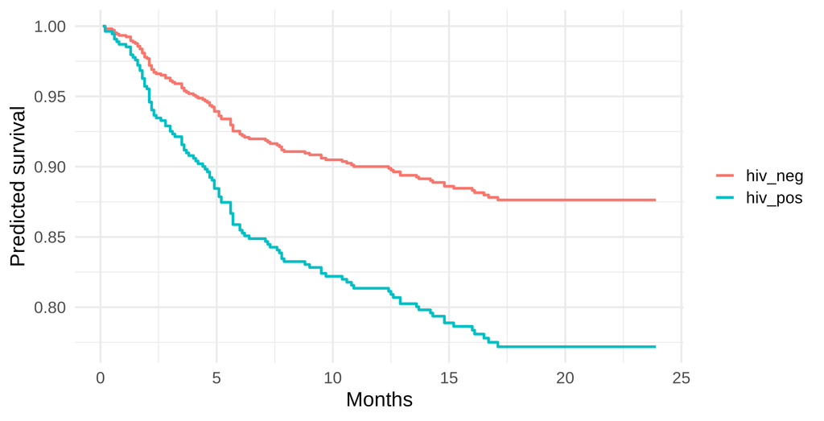

## HR is not a risk ratio

- An HR of 2 means the **rate** of dying is twice as high **at each moment**, not that the **cumulative risk** is doubled
- With **rare** events they are close; with common events they differ
- Report the HR **and** survival (or risk) at fixed times when possible

## Reporting a Cox model

- **Events and patients** in each group; **median follow-up**
- **Crude and adjusted HRs with 95% CI** (state the covariates and why)
- The **reference** category and the **unit** of each continuous variable
- The result of the **proportional-hazards check** (Session 5)

## 🔧 Switch to R — Lab 4

**File:** `survival-workshop/labs/lab4_cox.R`

- `coxph()` · `exp(coef())` · `confint()`
- multivariable model, `tbl_regression(exponentiate = TRUE)`
- rescale age · events per coefficient · predicted survival

**Time:** 40 minutes · answer the Q questions in the comments

## Self-check quiz (1/5)

A Cox model gives HR = 2.0 (95% CI 1.2 to 3.3) for HIV-positive vs negative patients. Which interpretation is correct?

- HIV-positive patients are twice as likely to die during the study
- HIV-positive patients survive twice as long as negative patients
- At any time, the hazard of death is about twice as high with HIV
- Two per cent more HIV-positive patients die in every single month

## Self-check quiz (2/5)

Age has HR = 1.02 per year. What is the approximate HR per 10 years?

- About 1.20, because 0.02 is added 10 times
- About 1.22, because 1.02 multiplied by itself 10 times
- About 2.0, because 10 years doubles the hazard
- About 1.02, since the hazard ratio does not depend on the unit

## Self-check quiz (3/5)

Why is the number of events, not the number of patients, the key constraint on a Cox model?

- Each patient appears just one time in the data set used to fit it
- Cox models can only use the patients who died during follow-up
- Information comes from events; censored patients add at-risk time
- Censored patients are removed before the model is fitted to the rest

## Self-check quiz (4/5)

In a Cox model the HR for treatment (DOT vs self-administered) is 0.57. What does this say?

- DOT patients have a 57% probability of dying during follow-up
- DOT patients live 43% longer than self-administered patients do
- The hazard is 0.57 times lower with self-administered treatment
- With other variables fixed, hazard of death is about 43% lower

## Self-check quiz (5/5)

What is the baseline hazard h0(t) in the Cox model?

- The hazard for a patient with all covariates at reference values
- The proportion of patients who died during the follow-up period
- The hazard ratio of the first predictor entered into the model
- A constant rate that must be estimated before the model is fitted

## Score and take-home

**Your score:**

- **HR = exp(β)**: the multiplicative change in the hazard, at any time
- **Adjusted HRs** from a multivariable model; report CI and reference groups
- **Rescale** continuous variables; check **events per coefficient**
- HR is a **rate ratio**, not a risk ratio; the model can predict **survival curves**

**Next:** Session 5: assumptions and reporting